# t-SNE vs. PCA y MDS en la base de datos Fashion-MNIST

### Andreu Cantó y Amparo Gálvez

Vamos a trabajar en esta práctica con t-SNE comparándolo otra vez con reductores de dimensionalidad de tipo lineal como son PCA y MDS sobre imágenes. Esta vez, en lugar de usar el clásico repositorio MNIST, vamos a utilizar otro que se considera una evolución del anterior: Fashion-MNIST. Este es un dataset con 70000 productos de ropa y complementos en forma de fotos de 28x28 en escala de grises. Existen 10 categorias de productos con 7000 imágenes por categoria. El training set tiene 60000 imagenes y el test set tiene 10000. Los miembros del dataset están etiquetados de la siguiente manera:

0 T-shirt/top 1 Trouser 2 Pullover 3 Dress 4 Coat 5 Sandal 6 Shirt 7 Sneaker 8 Bag 9 Ankle boot

La siguiente caja define una función para cargar los ficheros comprimidos que se te proporcionan, de nombres train-images-idx3-ubyte.gz y train-labels-idx1-ubyte.gz

```
(60000, 784)
```

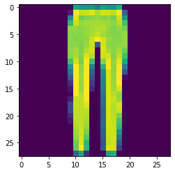

```python
import numpy as np
import time
import pandas as pd
import numpy as np
import matplotlib.pyplot as plt
import matplotlib.patheffects as PathEffects

def load_mnist(path, kind='train'):
    import os
    import gzip
    import numpy as np

    """Load MNIST data from `path`"""
    labels_path = os.path.join(path,
                               '%s-labels-idx1-ubyte.gz'
                               % kind)
    images_path = os.path.join(path,
                               '%s-images-idx3-ubyte.gz'
                               % kind)

    with gzip.open(labels_path, 'rb') as lbpath:
        labels = np.frombuffer(lbpath.read(), dtype=np.uint8,
                               offset=8)

    with gzip.open(images_path, 'rb') as imgpath:
        images = np.frombuffer(imgpath.read(), dtype=np.uint8,
                               offset=16).reshape(len(labels), 784)

    return images, labels

#Pon aquí el path dondde has alojado las imágenes.
#Si estas en windows y estan en el mismo directorio que el Notebook, este path funciona
path = '.\\'
X_train, y_train = load_mnist(path, kind='train')

#la talla debe salirte (60000, 784)
print(X_train.shape)

%pylab inline
#visualizamos una imagen para ver su aspecto
imgplot = plt.imshow(np.reshape(X_train[12457],(28,28)))
plt.show()
```

Importamos las librerias necesarias

```python
import time
import pandas as pd
import numpy as np
import matplotlib.pyplot as plt
import matplotlib.patheffects as PathEffects
%matplotlib inline

import seaborn as sns
sns.set_style('darkgrid')
sns.set_palette('muted')
sns.set_context("notebook", font_scale=1.5,
                rc={"lines.linewidth": 2.5})
#semilla para mantener reproducibilidad
RS = 123
```

La segunda función plot_components es parecida a la función de la práctica anterior. Muestra el los puntos en el mapa 2D de color negro y saca algunos representantes en forma de fotos eligiendo puntos al azar (homogeneamente)

```python
# Utility function to visualize the outputs of PCA and t-SNE

def fashion_scatter(x, colors):
    # choose a color palette with seaborn.
    num_classes = len(np.unique(colors))
    palette = np.array(sns.color_palette("hls", num_classes))

    # create a scatter plot.
    f = plt.figure(figsize=(8, 8))
    ax = plt.subplot(aspect='equal')
    sc = ax.scatter(x[:,0], x[:,1], lw=0, s=40, c=palette[colors.astype(int)])
    plt.xlim(-25, 25)
    plt.ylim(-25, 25)
    ax.axis('off')
    ax.axis('tight')

    # add the labels for each digit corresponding to the label
    txts = []

    for i in range(num_classes):

        # Position of each label at median of data points.

        xtext, ytext = np.median(x[colors == i, :], axis=0)
        txt = ax.text(xtext, ytext, str(i), fontsize=24)
        txt.set_path_effects([
            PathEffects.Stroke(linewidth=5, foreground="w"),
            PathEffects.Normal()])
        txts.append(txt)

    return f, ax, sc, txts

# source: https://jakevdp.github.io/PythonDataScienceHandbook/05.10-manifold-learning.html
def plot_components(data,images=None, ax=None,
                    thumb_frac=0.05, cmap='gray'):
    ax = ax or plt.gca()

    proj = data
    ax.plot(proj[:, 0], proj[:, 1], '.k')

    if images is not None:
        min_dist_2 = (thumb_frac * max(proj.max(0) - proj.min(0))) ** 2
        shown_images = np.array([2 * proj.max(0)])
        for i in range(data.shape[0]):
            dist = np.sum((proj[i] - shown_images) ** 2, 1)
            if np.min(dist) < min_dist_2:
                # don't show points that are too close
                continue
            shown_images = np.vstack([shown_images, proj[i]])
            imagebox = offsetbox.AnnotationBbox(
                offsetbox.OffsetImage(np.reshape(images[i],(28,28)), cmap=cmap),
                                      proj[i])
            ax.add_artist(imagebox)
```

Para estar seguros de que no colapsamos el ordenador, vamos a elegir solo 2000 ejempos del dataset. Primero baraja el dataset (shuffle)para asegurarte de están homogeneamente repartidos

```python
#Baraja aquí el dataset X_train y asegurate de que hay correspondencia con y_train
indices_barajados = np.arange(len(X_train))
np.random.shuffle(indices_barajados)

# Aplicamos el indice de barajado
X_train_barajado = X_train[indices_barajados]
y_train_barajado = y_train[indices_barajados]


#Subset first 20k data points to visualize
x_subset = X_train[0:2000]
y_subset = y_train[0:2000]

print(np.unique(y_subset))
```

```
[0 1 2 3 4 5 6 7 8 9]
```

## PCA

Vamos a usar primero PCA (método lineal) para tratar el problema. Vamos a usar PCA con n_components=4 para obtener proyecciones en un espacio 4D y ver cómo se distribuye la cantida de varianza que explica cada dimensión. Puedes dejar el resto de parametros por defecto o jugar un poco con ellos sobre la base de los parámetros por defecto

```python
from sklearn.decomposition import PCA

time_start = time.time()
#Configura la PCA para cuatro componentes. Puedes jugar con alguno de los parámetros
pca = PCA(n_components=4)
pca_result = pca.fit_transform(x_subset)

#imprime el atributo que explica la ratio de varianza
print('Variance explained per principal component: {}'.format(pca.explained_variance_ratio_))

print ('PCA done! Time elapsed: {} seconds'.format(time.time()-time_start))
```

```
Variance explained per principal component: [0.29415547 0.18213408 0.0585316  0.05250544]
PCA done! Time elapsed: 0.02330780029296875 seconds
```

Observa arriba la varianza explicada por los cuatro primeros componentes principales.

Vamos a almacenar los cuatro primeros componentes principales (cuatro primeros autovectores) en un nuevo DataFrame y comprobamos la cantidad de varianza explicada por esos 4 componentes.

```python
pca_df = pd.DataFrame(columns = ['pca1','pca2','pca3','pca4'])
pca_result = pca.fit_transform(x_subset)
pca_df['pca1'] = pca_result[:,0]
pca_df['pca2'] = pca_result[:,1]
pca_df['pca3'] = pca_result[:,2]
pca_df['pca4'] = pca_result[:,3]
```

**Actividad 1** Justifica aquí en función de los porcentajes de varianza explicada si es coherente quedarnos con únicamente las dos primeras dimensiones. Piensa que los valores están ordenados en forma decreciente y que ningun valor de los restantes supera el valor del cuarto.

Permaneceremos con las dos primeras variables, ya que las siguientes tienen una varianza explicativa considerablemente baja.

Vamos a visualizar los resultados sobre las dos primeras componentes principales calculadas por PCA

```
(<Figure size 576x576 with 1 Axes>,
 <AxesSubplot:>,
 [Text(734.1331327223495, -700.5759262313901, '0'),
```

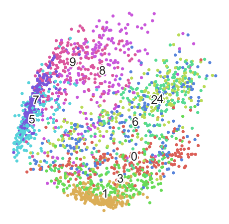

```python
top_two_comp = pca_df[['pca1','pca2']] # taking first and second principal component

fashion_scatter(top_two_comp.values,y_subset) # Visualizing the PCA output
```

**Actividad 2** Juzga sobre la separabilidad de los grupos creados

Vamos a visualizar, como en la práctica anterior, la proyección 2D mostrando sobre ellos algunos puntos originales del dataset. Usa la función 'plot_components' sobre los puntos transformados y el dataset original. Regula el parámetro 'thumb_frac' para decidir el número de puntos que muestras (fotos).

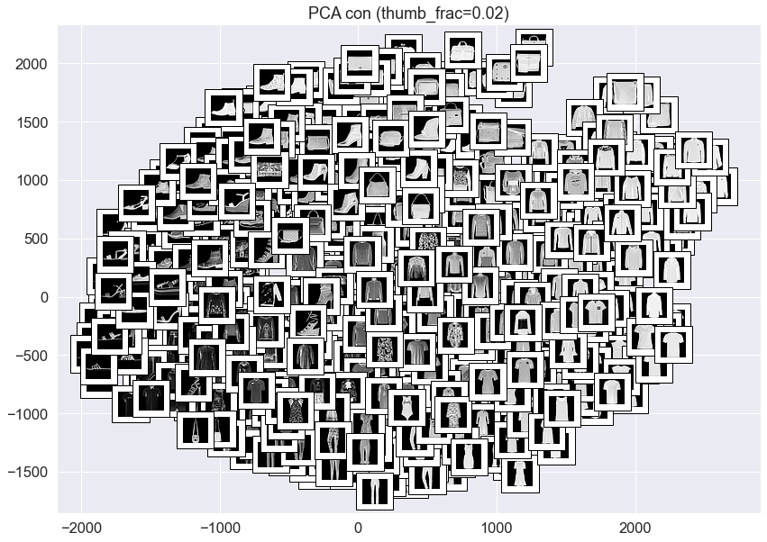

[figure not shown]

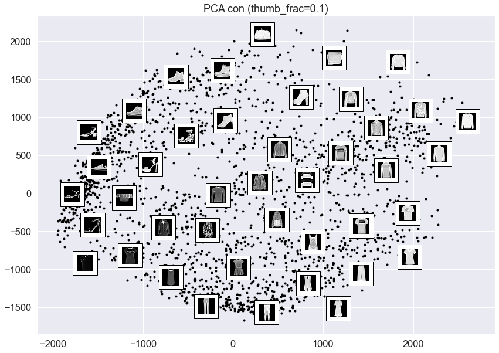

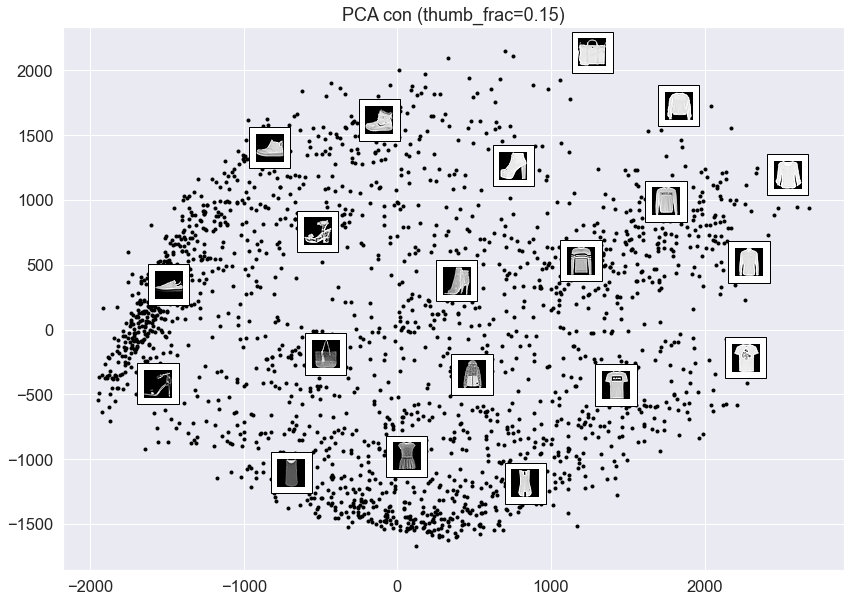

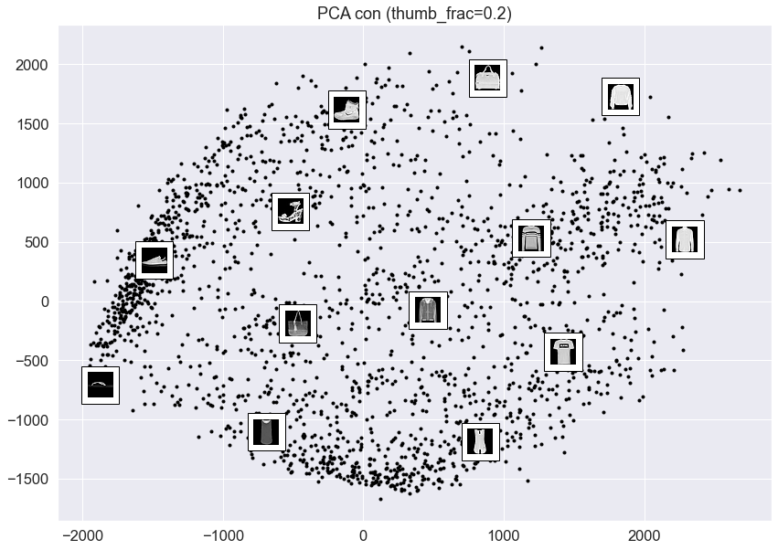

```python
from matplotlib import offsetbox
thumb_fracs = [0.02, 0.05, 0.1, 0.15, 0.2]
for thumb_frac in thumb_fracs:
    fig, ax = plt.subplots(figsize=(14, 10))
    plot_components(top_two_comp.values, x_subset, ax=None,
                    thumb_frac=thumb_frac, cmap='gray')
    plt.title(f"PCA con (thumb_frac={thumb_frac})")
    plt.show()
```

Como puedes ver, PCA ha intentado (tu juzgarás el éxito) separar los diferentes puntos y formar clusters basados en la simularidad encontrada. EL gráfico obtenido puede usarse con finalidad exploratoria y las componentes principales encontradas pueden usarse como entrada a algún método de agrupamiento.

## MDS

Vamos a probar ahora con otro método lineal: **Multi-Dimensional Scaling (MDS)**. Aquí simplemente vamos a cargar MDS con n_components=2 para embeber en un espacio de 2D. Puedes probar con más configuraciones si lo deseas.

```
MDS done! Time elapsed: 131.44793391227722 seconds
```

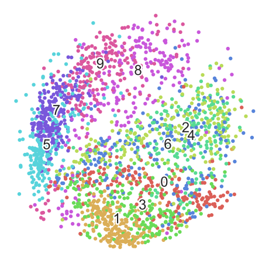

```python
from sklearn.manifold import MDS
#prepara el modelo MDS
embedding = MDS(n_components=2)
Xmds_transformed = embedding.fit_transform(x_subset)
fashion_scatter(Xmds_transformed,y_subset)

print ('MDS done! Time elapsed: {} seconds'.format(time.time()-time_start))
```

**Actividad 3.0**. Explica brevemente en qué consiste el método MDS y cuál es la diferencia respecto a PCA en relación al output que saca, es decir qué diferencia hay en la forma de obtener los datos por PCA y por MDS.

PCA se orienta hacia la explicación de la variabilidad presente en los datos, mientras que MDS se enfoca en la conservación de las relaciones de distancia entre las observaciones.

**Actividad 3.1**. Observa los resultados de MDS y compáralos con los de PCA. Describe sus parecidos y diferencias.

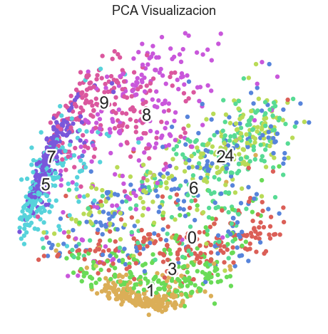

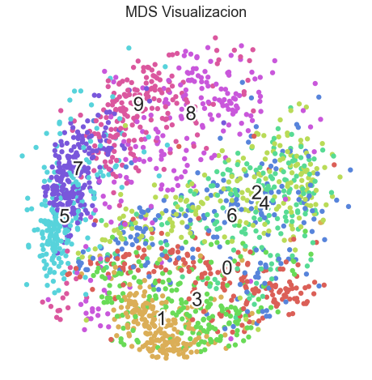

```python
fashion_scatter(top_two_comp.values,y_subset) #PCA
plt.title('PCA Visualizacion')
plt.show()

fashion_scatter(Xmds_transformed,y_subset) #MDS
plt.title('MDS Visualizacion')
plt.show()
```

## t-SNE

Vamos a hora a trabajar con t-NSE. Prepara el modelo para cambiar explícitamente los atributos: perplexity, num iteraciones, early_exageration,learning_rate, n_iter_without_progress Puedes primero preparar el modelo por defecto

```python
from sklearn.manifold import TSNE
import time
time_start = time.time()

modelo_tsne = TSNE(n_components=2, perplexity=30, n_iter=1000, early_exaggeration=12, learning_rate='auto', n_iter_without_progress=300)
fashion_tsne = modelo_tsne.fit_transform(x_subset)

print ('t-SNE done! Time elapsed: {} seconds'.format(time.time()-time_start))
```

```
t-SNE done! Time elapsed: 5.40387749671936 seconds
```

**Actividad 4.0:** Indica la relación del tiempo que ha tardado t-SNE comparándola con PCA o MDS (basta una apreciación subjetiva, no hace falta medir)

Al usar PCA, obtenemos los resultados en menos de un segundo, TSNE tarda unos pocos segundos y MDS necesita mas de 1 minuto para completarse.

Vamos a visualizar la salida de t-SNE usando la función fashion_scatter()

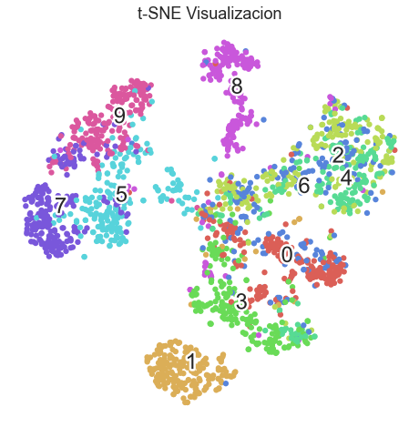

```python
fashion_scatter(fashion_tsne,y_subset)
plt.title('t-SNE Visualizacion')
plt.show()
```

Vamos a visualizar ahora alguno de los contenidos en el espacio original de alguno de los puntos embebidos en el espacio 2D. Para ello usa la función plot_components() con un thumb_frac adecuado

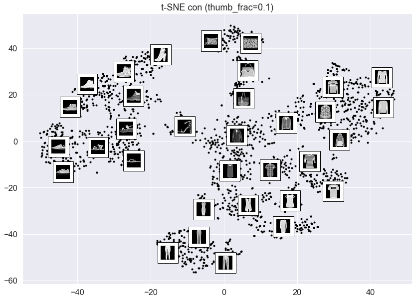

```python
fig, ax = plt.subplots(figsize=(14, 10))
plot_components(fashion_tsne, x_subset, ax=None,
                    thumb_frac=0.1, cmap='gray')
plt.title("t-SNE con (thumb_frac=0.1)")
plt.show()
```

**Actividad 4.1:** Valora los resultados que obtienes respecto a si tiene sentido la visualización que proporciona t-SNE acerca de la estructura del dataset.

En la información de TSNE de la libreria scikit se indica que:

"It is highly recommended to use another dimensionality reduction method (e.g., PCA for dense data or TruncatedSVD for sparse data) to reduce the number of dimensions to a reasonable amount (e.g., 50) if the number of features is very high. This will suppress some noise and speed up the computation of pairwise distances between samples."

Vamos a seguir esta recomendación y vamos a reducir el número de dimensiones usando PCA antes de alimentar TSNE con la base de datos resultante de esta transformación. Usa pca para crear una base de datos de 50 dimensiones. Usaremos luego ese dataset para alimentar TSNE.

```python
time_start = time.time()

#modelo de PCA con 50 componentes principales
pca_50 = PCA(n_components=50)
pca_result_50 = pca_50.fit_transform(x_subset)

print('PCA with 50 components done! Time elapsed: {} seconds'.format(time.time()-time_start))

print('Cumulative variance explained by 50 principal components: {}'.format(np.sum(pca_50.explained_variance_ratio_)))
```

```
PCA with 50 components done! Time elapsed: 0.06103920936584473 seconds
Cumulative variance explained by 50 principal components: 0.8720899422601909
```

Aplica esta base de datos a TSNE

```python
import time
time_start = time.time()

modelo_tsne_pca = TSNE(n_components=2)
fashion_pca_tsne = modelo_tsne_pca.fit_transform(pca_result_50)

print('t-SNE on PCA result done! Time elapsed: {} seconds'.format(time.time() - time_start))
```

```
t-SNE on PCA result done! Time elapsed: 5.116837501525879 seconds
```

Visualizando:

```
(<Figure size 576x576 with 1 Axes>,
 <AxesSubplot:>,
 [Text(19.213898, -14.7567215, '0'),
```

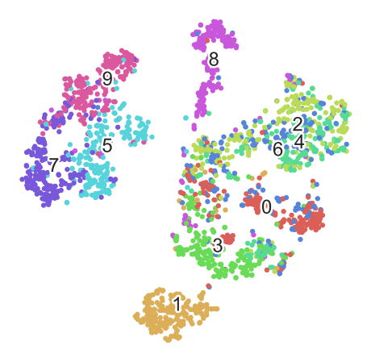

```python
fashion_scatter(fashion_pca_tsne, y_subset)
```

**Actividad 4.2:** Ejecuta varias veces (4 ó 5) t-SNE imprimiendo el valor de la divergencia KL. Indica si las divergencias obtenidas varían mucho entre las ejecuciones y también compara visualmente los resultados de divergencias más alta y más baja e indica si hay diferencias apreciables con este dataset.

```python
num_ej = 4
dive = []
for i in range(num_ej):
    print(f"\nEjecución {i + 1}")

#Ejecutar t-SNE
    modelo_tsne_pca = TSNE(n_components=2, random_state=RS)
    fashion_pca_tsne = modelo_tsne_pca.fit_transform(pca_result_50)

#Imprimir el valor de la divergencia KL
    kl_dive = modelo_tsne_pca.kl_divergence_
    print(f"Divergencia KL: {kl_dive}")
    dive.append(kl_divergence)
```

[output not shown]

Visualiza una ejecución de t-SNE como has hecho con PCA usando plot_components()

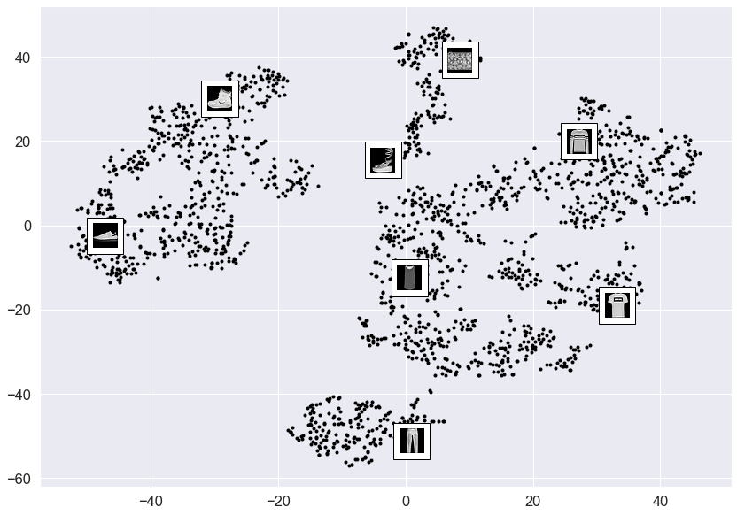

```python
fig, ax = plt.subplots(figsize=(14, 10))
plot_components(fashion_pca_tsne, x_subset, ax=None,
                    thumb_frac=0.25, cmap='gray')
plt.show()
```

**Actividad 5** Comenta los resultados tras reducir la dimensionalidad con PCA. ¿Ha mejorado el resultado respecto a las ejecuciones sin PCA previo? ¿Si lo ha hecho, en qué sentido? ¿Has necesitado pasar mucho tiempo ajustando parámetros? ¿Qué parámetro resulta más sensible sobre t-SNE?

Aunque no fue necesario ajustar extensivamente los parámetros, se debe explorar la sensibilidad a otros factores de t-SNE para evaluar su impacto.